# Derivative

## Definition

We write this analyticaly as:

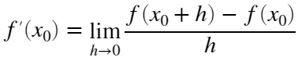

## MPK Average Output Per Additional Worker

Let's consider a cobb-douglas production function again.

If you own a firm, you would be very interested in how much additional output you can get from one more unit of capital of one more labor hired. If you know that, you can compare that against the cost of more capital and labor and determine if it is optimal to choose to increase capital and/or labor.

The above formula is calculating the average additional output produced by h more workers:

```matlab
clear all;
% fixed capital level
K = 1;
% current labor level
L = 2;

% Cobb Douglas Production Parameters
alpha = 0.5;
beta = 1-alpha;

% Output at x0
f_x0 = (K^alpha)*(L.^beta);

% a vector of h
h = linspace(0, 14, 100);

% output at f_x0_plus_h
x0_plus_h = L+h;
f_x0_plus_h = (K^alpha)*((x0_plus_h).^beta);

% derivatie
f_prime_x0 = (f_x0_plus_h - f_x0)./h;

% Show Results in table
T = table(h', x0_plus_h', f_x0_plus_h', f_prime_x0');
T.Properties.VariableNames = {'h', 'x0_plus_h', 'f_x0_plus_h', 'f_prime_x0'};
T
```

T = 100×4 table

|  | h | x0_plus_h | f_x0_plus_h | f_prime_x0 |
| --- | --- | --- | --- | --- |
| 1 | 0 | 2.0000 | 1.4142 | NaN |
| 2 | 0.1414 | 2.1414 | 1.4634 | 0.3475 |
| 3 | 0.2828 | 2.2828 | 1.5109 | 0.3419 |
| 4 | 0.4242 | 2.4242 | 1.5570 | 0.3366 |
| 5 | 0.5657 | 2.5657 | 1.6018 | 0.3316 |
| 6 | 0.7071 | 2.7071 | 1.6453 | 0.3268 |
| 7 | 0.8485 | 2.8485 | 1.6877 | 0.3224 |
| 8 | 0.9899 | 2.9899 | 1.7291 | 0.3181 |
| 9 | 1.1313 | 3.1313 | 1.7696 | 0.3141 |
| 10 | 1.2727 | 3.2727 | 1.8091 | 0.3102 |

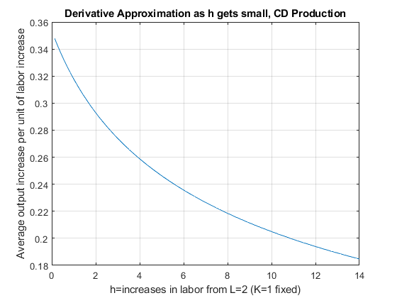

```matlab
% Graph
close all;
figure();
plot(h, f_prime_x0);
grid on;
ylabel('Average output increase per unit of labor increase')
xlabel('h=increases in labor from L=2 (K=1 fixed)')
title('Derivative Approximation as h gets small, CD Production')
```

## Marginal Product of Additional Workers (Discrete Workers)

Suppose we can not hire fractions of workers, but have to hire 1, 2, 3, etc.. What is the marginal product of each additional worker?

```matlab
% fixed capital level
K = 1;
% current labor level
L = [1,2,3,4,5,6,7,8,9,10,11,12,13,14,15];

% Cobb Douglas Production Parameters
alpha = 0.5;
beta = 1-alpha;

% Output at x0
f_x0 = (K^alpha)*(L.^beta);

% a vector of h
h = 1;

% output at f_x0_plus_h
x0_plus_h = L+h;
f_x0_plus_h = (K^alpha)*((x0_plus_h).^beta);

% derivatie
f_prime_x0 = (f_x0_plus_h - f_x0)./h;

% Show Results in table
T = table(L', x0_plus_h', f_x0_plus_h', f_prime_x0');
T.Properties.VariableNames = {'L', 'x0_plus_h', 'f_x0_plus_h', 'f_prime_x0'};
T
```

T = 15×4 table

|  | L | x0_plus_h | f_x0_plus_h | f_prime_x0 |
| --- | --- | --- | --- | --- |
| 1 | 1 | 2 | 1.4142 | 0.4142 |
| 2 | 2 | 3 | 1.7321 | 0.3178 |
| 3 | 3 | 4 | 2.0000 | 0.2679 |
| 4 | 4 | 5 | 2.2361 | 0.2361 |
| 5 | 5 | 6 | 2.4495 | 0.2134 |
| 6 | 6 | 7 | 2.6458 | 0.1963 |
| 7 | 7 | 8 | 2.8284 | 0.1827 |
| 8 | 8 | 9 | 3.0000 | 0.1716 |
| 9 | 9 | 10 | 3.1623 | 0.1623 |
| 10 | 10 | 11 | 3.3166 | 0.1543 |

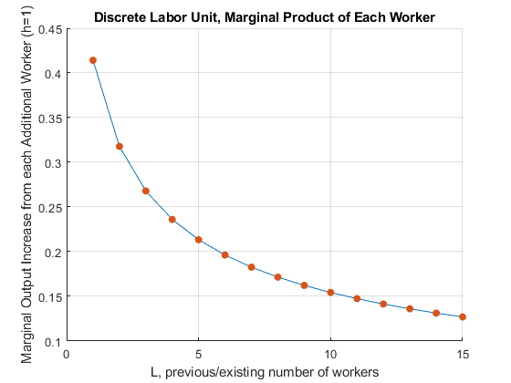

```matlab
% Graph
close all;
figure();
hold on;
plot(L, f_prime_x0);
scatter(L, f_prime_x0,'filled');
grid on;
ylabel('Marginal Output Increase from each Additional Worker (h=1)')
xlabel('L, previous/existing number of workers')
title('Discrete Labor Unit, Marginal Product of Each Worker')
```

## Marginal Product of Additional Workers Different Capital (Discrete Workers)

Suppose we can not hire fractions of workers, but have to hire 1, 2, 3, etc.. What is the marginal product of each additional worker?

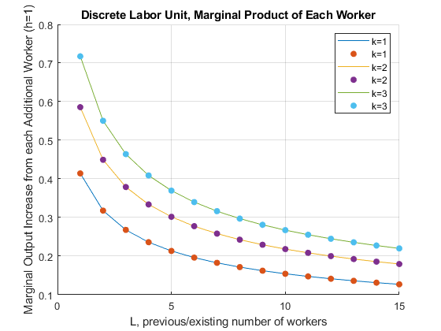

```matlab
% fixed capital level
K1 = 1;
[f_prime_x0_K1, L] = MPKdiscrete(K1);
K2 = 2;
[f_prime_x0_K2, L] = MPKdiscrete(K2);
K3 = 3;
[f_prime_x0_K3, L] = MPKdiscrete(K3);

% Graph
close all;
figure();
hold on;
plot(L, f_prime_x0_K1);
scatter(L, f_prime_x0_K1,'filled');
plot(L, f_prime_x0_K2);
scatter(L, f_prime_x0_K2,'filled');
plot(L, f_prime_x0_K3);
scatter(L, f_prime_x0_K3,'filled');
grid on;
ylabel('Marginal Output Increase from each Additional Worker (h=1)')
xlabel('L, previous/existing number of workers')
title('Discrete Labor Unit, Marginal Product of Each Worker')
legend(['k=',num2str(K1)], ['k=',num2str(K1)],...
    ['k=',num2str(K2)],['k=',num2str(K2)],...
['k=',num2str(K3)],['k=',num2str(K3)]);
```

```matlab
function [f_prime_x0, L] = MPKdiscrete(K)
% current labor level
L = [1,2,3,4,5,6,7,8,9,10,11,12,13,14,15];

% Cobb Douglas Production Parameters
alpha = 0.5;
beta = 1-alpha;

% Output at x0
f_x0 = (K^alpha)*(L.^beta);

% a vector of h
h = 1;

% output at f_x0_plus_h
x0_plus_h = L+h;
f_x0_plus_h = (K^alpha)*((x0_plus_h).^beta);

% derivatie
f_prime_x0 = (f_x0_plus_h - f_x0)./h;

end
```